# Final Paper

```python
%%html
<a href="https://en.wikipedia.org/wiki/Risk_parity">Risk Parity Wikipedia</a>
```

[Risk Parity Wikipedia](https://en.wikipedia.org/wiki/Risk_parity)

```python
import pandas as pd
import pandas_datareader.data as web
import numpy as np
import html
import datetime
import math
import matplotlib.pyplot as plt
from scipy.optimize import minimize
import scipy.optimize as sco
from pandas.plotting import register_matplotlib_converters
TOLERANCE = 1e-10
```

```python
np.random.seed(0)
register_matplotlib_converters()
```

```python
# import stock adj close price from Yahoo Finance
# '^IXIC' = NASDAQ Composite
# ^DJI = Dow Jones (U.S.)
# ^GSPC = S&P 500 (U.S.)
# '^N225' = Nikkie 225 (JPN)
# ^HSI = Hang Seng (Hong Kong)
# ^GDAXI = DAX (Germany)
# TY=F   = 10 year U.S. Treasury Note Future
# ^TNX = Treasury Yield 10 Years
# GC=F = Gold Future
# SI=F = Silver Future
# 'CL=F' Crude Oil Jun 20 Future
# BTC=F Bitcoin Future
# BRK-A Berkshire Hathaway

yahoo_tickers = [
                'TY=F','^GSPC', 'AMZN','JNJ',
                'GC=F','^N225'
                ]

start_date = datetime.datetime(2019, 5, 1)

end_date = datetime.datetime(2020, 5, 1)

prices = pd.DataFrame([web.DataReader(t,'yahoo', start_date, end_date).loc[:, 'Adj Close']
                       for t in yahoo_tickers],index=yahoo_tickers).T.asfreq('B').ffill()

prices
```

| Date | TY=F | ^GSPC | AMZN | JNJ | GC=F | ^N225 |
| --- | --- | --- | --- | --- | --- | --- |
| 2019-05-01 | 123.578003 | 2923.729980 | 1911.520020 | 138.093307 | 1281.400024 | NaN |
| 2019-05-02 | 123.171997 | 2917.520020 | 1900.819946 | 137.441513 | 1269.699951 | NaN |
| 2019-05-03 | 123.344002 | 2945.639893 | 1962.459961 | 138.151672 | 1279.199951 | NaN |
| 2019-05-06 | 123.625000 | 2932.469971 | 1950.550049 | 138.229492 | 1281.699951 | NaN |
| 2019-05-07 | 124.015999 | 2884.050049 | 1921.000000 | 136.167099 | 1283.500000 | 21923.720703 |
| ... | ... | ... | ... | ... | ... | ... |
| 2020-04-27 | 138.609375 | 2878.479980 | 2376.000000 | 154.289993 | 1720.300049 | 19783.220703 |
| 2020-04-28 | 139.015625 | 2863.389893 | 2314.080078 | 151.389999 | 1721.000000 | 19771.189453 |
| 2020-04-29 | 139.250000 | 2939.510010 | 2372.709961 | 150.240005 | 1722.199951 | 19771.189453 |
| 2020-04-30 | 139.000000 | 2912.429932 | 2474.000000 | 150.039993 | 1695.400024 | 20193.689453 |
| 2020-05-01 | 139.062500 | 2830.709961 | 2286.040039 | 148.289993 | 1710.199951 | 19619.349609 |

263 rows × 6 columns

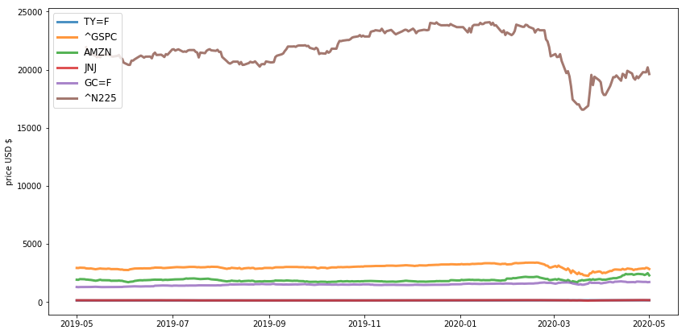

```python
# prices from 05-01-2019 to 05-01-2020
plt.figure(figsize=(14, 7))
for c in prices.columns.values:
    plt.plot(prices.index, prices[c], lw=3, alpha=0.8,label=c)
plt.legend(loc='upper left', fontsize=12)
plt.ylabel('price USD $')
plt.show()
```

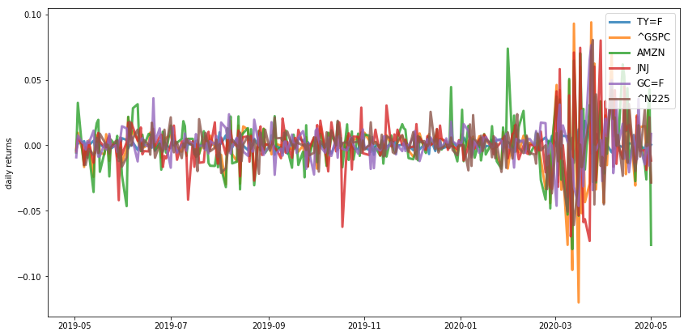

```python
# percentage change of returns

returns = prices.pct_change()
plt.figure(figsize=(14, 7))
for c in returns.columns.values:
    plt.plot(returns.index, returns[c], lw=3, alpha=0.8,label=c)
plt.legend(loc='upper right', fontsize=12)
plt.ylabel('daily returns')
plt.show()
```

## Risk Free Rate

https://www.treasury.gov/resource-center/data-chart-center/interest-rates/pages/textview.aspx?data=yield

```python
returns = prices.pct_change()
mean_returns = returns.mean()
cov_matrix = returns.cov()
num_portfolios = 50000
risk_free_rate = 0.17 / 100
```

```python
def portfolio_annualised_performance(weights, mean_returns, cov_matrix):
    returns = np.sum(mean_returns*weights ) *252
    std = np.sqrt(np.dot(weights.T, np.dot(cov_matrix, weights))) * np.sqrt(252)
    return std, returns

def random_portfolios(num_portfolios, mean_returns, cov_matrix, risk_free_rate):
    results = np.zeros((3,num_portfolios))
    weights_record = []
    for i in range(num_portfolios):
        weights = np.random.random(len(yahoo_tickers))
        weights /= np.sum(weights)
        weights_record.append(weights)
        portfolio_std_dev, portfolio_return = portfolio_annualised_performance(weights, mean_returns, cov_matrix)
        results[0,i] = portfolio_std_dev
        results[1,i] = portfolio_return
        results[2,i] = (portfolio_return - risk_free_rate) / portfolio_std_dev
    return results, weights_record
```

```python
def display_simulated_ef_with_random(mean_returns, cov_matrix, num_portfolios, risk_free_rate):
    results, weights = random_portfolios(num_portfolios,mean_returns, cov_matrix, risk_free_rate)

    max_sharpe_idx = np.argmax(results[2])
    sdp, rp = results[0,max_sharpe_idx], results[1,max_sharpe_idx]
    max_sharpe_allocation = pd.DataFrame(weights[max_sharpe_idx],index=prices.columns,columns=['allocation'])
    max_sharpe_allocation.allocation = [round(i*100,2)for i in max_sharpe_allocation.allocation]
    max_sharpe_allocation = max_sharpe_allocation.T

    min_vol_idx = np.argmin(results[0])
    sdp_min, rp_min = results[0,min_vol_idx], results[1,min_vol_idx]
    min_vol_allocation = pd.DataFrame(weights[min_vol_idx],index=prices.columns,columns=['allocation'])
    min_vol_allocation.allocation = [round(i*100,2)for i in min_vol_allocation.allocation]
    min_vol_allocation = min_vol_allocation.T

    print ("-"*80)
    print ("Maximum Sharpe Ratio Portfolio Allocation\n")
    print ("Annualized Return:", round(rp,2))
    print ("Annualized Volatility:", round(sdp,2))
    print ("\n")
    print (max_sharpe_allocation)
    print ("-"*80)
    print ("Minimum Volatility Portfolio Allocation\n")
    print ("Annualized Return:", round(rp_min,2))
    print ("Annualized Volatility:", round(sdp_min,2))
    print ("\n")
    print (min_vol_allocation)

    plt.figure(figsize=(10, 7))
    plt.scatter(results[0,:],results[1,:],c=results[2,:],cmap='YlGnBu', marker='o', s=10, alpha=0.3)
    plt.colorbar()
    plt.scatter(sdp,rp,marker='*',color='r',s=500, label='Maximum Sharpe ratio')
    plt.scatter(sdp_min,rp_min,marker='*',color='g',s=500, label='Minimum volatility')
    plt.title('Simulated Portfolio Optimization based on Efficient Frontier')
    plt.xlabel('Annualized volatility')
    plt.ylabel('Annualized returns')
    plt.legend(labelspacing=0.8)
```

```
--------------------------------------------------------------------------------
Maximum Sharpe Ratio Portfolio Allocation

Annualized Return: 0.16
Annualized Volatility: 0.07


             TY=F  ^GSPC   AMZN   JNJ  GC=F  ^N225
allocation  53.77   1.53  12.64  8.85  21.5   1.71
--------------------------------------------------------------------------------
Minimum Volatility Portfolio Allocation

Annualized Return: 0.1
Annualized Volatility: 0.05


             TY=F  ^GSPC  AMZN   JNJ  GC=F  ^N225
allocation  71.07  11.82  0.23  0.31  6.71   9.86
```

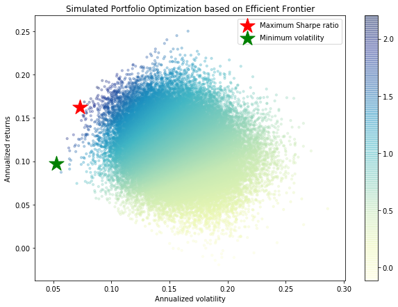

```python
display_simulated_ef_with_random(mean_returns, cov_matrix, num_portfolios, risk_free_rate)
```

```python
# constraints of weights to sum up to 100%
constraints = ({'type': 'eq', 'fun': lambda x: np.sum(x) - 1})
```

```python
def neg_sharpe_ratio(weights, mean_returns, cov_matrix, risk_free_rate):
    p_var, p_ret = portfolio_annualised_performance(weights, mean_returns, cov_matrix)
    return -(p_ret - risk_free_rate) / p_var

def max_sharpe_ratio(mean_returns, cov_matrix, risk_free_rate):
    num_assets = len(mean_returns)
    args = (mean_returns, cov_matrix, risk_free_rate)
    constraints = ({'type': 'eq', 'fun': lambda x: np.sum(x) - 1})
    bound = (0.0,1.0)
    bounds = tuple(bound for asset in range(num_assets))
    result = sco.minimize(neg_sharpe_ratio, num_assets*[1./num_assets,], args=args,
                        method='SLSQP', bounds=bounds, constraints=constraints)
    return result
```

```python
def portfolio_volatility(weights, mean_returns, cov_matrix):
    return portfolio_annualised_performance(weights, mean_returns, cov_matrix)[0]

def min_variance(mean_returns, cov_matrix):
    num_assets = len(mean_returns)
    args = (mean_returns, cov_matrix)
    constraints = ({'type': 'eq', 'fun': lambda x: np.sum(x) - 1})
    bound = (0.0,1.0)
    bounds = tuple(bound for asset in range(num_assets))

    result = sco.minimize(portfolio_volatility, num_assets*[1./num_assets,], args=args,
                        method='SLSQP', bounds=bounds, constraints=constraints)

    return result
```

```python
def efficient_return(mean_returns, cov_matrix, target):
    num_assets = len(mean_returns)
    args = (mean_returns, cov_matrix)

    def portfolio_return(weights):
        return portfolio_annualised_performance(weights, mean_returns, cov_matrix)[1]

    constraints = ({'type': 'eq', 'fun': lambda x: portfolio_return(x) - target},
                   {'type': 'eq', 'fun': lambda x: np.sum(x) - 1})
    bounds = tuple((0,1) for asset in range(num_assets))
    result = sco.minimize(portfolio_volatility, num_assets*[1./num_assets,], args=args, method='SLSQP', bounds=bounds, constraints=constraints)
    return result


def efficient_frontier(mean_returns, cov_matrix, returns_range):
    efficients = []
    for ret in returns_range:
        efficients.append(efficient_return(mean_returns, cov_matrix, ret))
    return efficients
```

```python
def display_calculated_ef_with_random(mean_returns, cov_matrix, num_portfolios, risk_free_rate):
    results, _ = random_portfolios(num_portfolios,mean_returns, cov_matrix, risk_free_rate)

    max_sharpe = max_sharpe_ratio(mean_returns, cov_matrix, risk_free_rate)
    sdp, rp = portfolio_annualised_performance(max_sharpe['x'], mean_returns, cov_matrix)
    max_sharpe_allocation = pd.DataFrame(max_sharpe.x,index=prices.columns,columns=['allocation'])
    max_sharpe_allocation.allocation = [round(i*100,2)for i in max_sharpe_allocation.allocation]
    max_sharpe_allocation = max_sharpe_allocation.T

    min_vol = min_variance(mean_returns, cov_matrix)
    sdp_min, rp_min = portfolio_annualised_performance(min_vol['x'], mean_returns, cov_matrix)
    min_vol_allocation = pd.DataFrame(min_vol.x,index=prices.columns,columns=['allocation'])
    min_vol_allocation.allocation = [round(i*100,2)for i in min_vol_allocation.allocation]
    min_vol_allocation = min_vol_allocation.T

    print ("-"*80)
    print ("Maximum Sharpe Ratio Portfolio Allocation\n")
    print ("Annualised Return:", round(rp,2))
    print ("Annualised Volatility:", round(sdp,2))
    print ("\n")
    print (max_sharpe_allocation)
    print ("-"*80)
    print ("Minimum Volatility Portfolio Allocation\n")
    print ("Annualised Return:", round(rp_min,2))
    print ("Annualised Volatility:", round(sdp_min,2))
    print ("\n")
    print (min_vol_allocation)

    plt.figure(figsize=(10, 7))
    plt.scatter(results[0,:],results[1,:],c=results[2,:],cmap='YlGnBu', marker='o', s=10, alpha=0.3)
    plt.colorbar()
    plt.scatter(sdp,rp,marker='*',color='r',s=500, label='Maximum Sharpe ratio')
    plt.scatter(sdp_min,rp_min,marker='*',color='g',s=500, label='Minimum volatility')

    target = np.linspace(rp_min, 0.32, 50)
    efficient_portfolios = efficient_frontier(mean_returns, cov_matrix, target)
    plt.plot([p['fun'] for p in efficient_portfolios], target, linestyle='-', color='black', label='efficient frontier')
    plt.title('Calculated Portfolio Optimization based on Efficient Frontier')
    plt.xlabel('Annualized volatility')
    plt.ylabel('Annualized returns')
    plt.legend(labelspacing=0.8)
```

```
--------------------------------------------------------------------------------
Maximum Sharpe Ratio Portfolio Allocation

Annualised Return: 0.14
Annualised Volatility: 0.05


             TY=F  ^GSPC  AMZN   JNJ  GC=F  ^N225
allocation  79.91    0.0  8.62  4.63  6.84    0.0
--------------------------------------------------------------------------------
Minimum Volatility Portfolio Allocation

Annualised Return: 0.11
Annualised Volatility: 0.04


             TY=F  ^GSPC  AMZN   JNJ  GC=F  ^N225
allocation  85.42   6.12  3.48  2.74   0.0   2.25
```

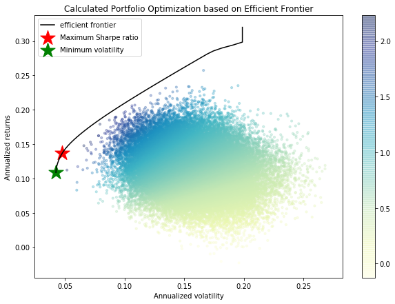

```python
display_calculated_ef_with_random(mean_returns, cov_matrix, num_portfolios, risk_free_rate)
```

```python
def display_ef_with_selected(mean_returns, cov_matrix, risk_free_rate):
    max_sharpe = max_sharpe_ratio(mean_returns, cov_matrix, risk_free_rate)
    sdp, rp = portfolio_annualised_performance(max_sharpe['x'], mean_returns, cov_matrix)
    max_sharpe_allocation = pd.DataFrame(max_sharpe.x,index=prices.columns,columns=['allocation'])
    max_sharpe_allocation.allocation = [round(i*100,2)for i in max_sharpe_allocation.allocation]
    max_sharpe_allocation = max_sharpe_allocation.T

    min_vol = min_variance(mean_returns, cov_matrix)
    sdp_min, rp_min = portfolio_annualised_performance(min_vol['x'], mean_returns, cov_matrix)
    min_vol_allocation = pd.DataFrame(min_vol.x,index=prices.columns,columns=['allocation'])
    min_vol_allocation.allocation = [round(i*100,2)for i in min_vol_allocation.allocation]
    min_vol_allocation = min_vol_allocation.T

    an_vol = np.std(returns) * np.sqrt(252)
    an_rt = mean_returns * 252

    print ("-"*80)
    print ("Maximum Sharpe Ratio Portfolio Allocation\n")
    print ("Annualized Return:", round(rp,2))
    print ("Annualized Volatility:", round(sdp,2))
    print ("\n")
    print (max_sharpe_allocation)
    print ("-"*80)
    print ("Minimum Volatility Portfolio Allocation\n")
    print ("Annualized Return:", round(rp_min,2))
    print ("Annualized Volatility:", round(sdp_min,2))
    print ("\n")
    print (min_vol_allocation)
    print ("-"*80)
    print ("Individual Stock Returns and Volatility\n")
    for i, txt in enumerate(prices.columns):
        print (txt,":","Annualized return",round(an_rt[i],2),", Annualized volatility:",round(an_vol[i],2))
    print ("-"*80)

    fig, ax = plt.subplots(figsize=(10, 7))
    ax.scatter(an_vol,an_rt,marker='o',s=200)

    for i, txt in enumerate(prices.columns):
        ax.annotate(txt, (an_vol[i],an_rt[i]), xytext=(10,0), textcoords='offset points')
    ax.scatter(sdp,rp,marker='*',color='r',s=500, label='Maximum Sharpe ratio')
    ax.scatter(sdp_min,rp_min,marker='*',color='g',s=500, label='Minimum volatility')

    target = np.linspace(rp_min, 0.34, 50)
    efficient_portfolios = efficient_frontier(mean_returns, cov_matrix, target)
    ax.plot([p['fun'] for p in efficient_portfolios], target, linestyle='-', color='black', label='efficient frontier')
    ax.set_title('Portfolio Optimization with Individual Stocks')
    ax.set_xlabel('Annualized volatility')
    ax.set_ylabel('Annualized returns')
    ax.legend(labelspacing=0.8)
```

```
--------------------------------------------------------------------------------
Maximum Sharpe Ratio Portfolio Allocation

Annualized Return: 0.14
Annualized Volatility: 0.05


             TY=F  ^GSPC  AMZN   JNJ  GC=F  ^N225
allocation  79.91    0.0  8.62  4.63  6.84    0.0
--------------------------------------------------------------------------------
Minimum Volatility Portfolio Allocation

Annualized Return: 0.11
Annualized Volatility: 0.04


             TY=F  ^GSPC  AMZN   JNJ  GC=F  ^N225
allocation  85.42   6.12  3.48  2.74   0.0   2.25
--------------------------------------------------------------------------------
Individual Stock Returns and Volatility

TY=F : Annualized return 0.12 , Annualized volatility: 0.06
^GSPC : Annualized return 0.02 , Annualized volatility: 0.32
AMZN : Annualized return 0.22 , Annualized volatility: 0.31
JNJ : Annualized return 0.11 , Annualized volatility: 0.3
GC=F : Annualized return 0.3 , Annualized volatility: 0.2
^N225 : Annualized return -0.08 , Annualized volatility: 0.23
--------------------------------------------------------------------------------
```

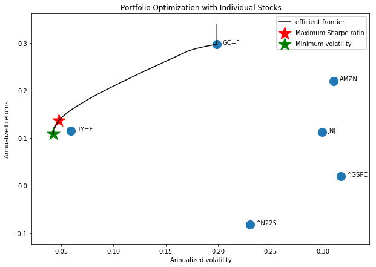

```python
display_ef_with_selected(mean_returns, cov_matrix, risk_free_rate)
```

### Risk Parity

The best known version of risk parity is the equally-weighted risk contributions portfolio method.

Equally-weighted risk contributions is not about "having the same volatility", it is about having each asset contributing in the same way to the portfolio overall volatility. For this we will have to define the contribution of each asset to the portfolio risk.

Consider a portfolio of $N$ assets

where the weight of asset is $ w_i $

$ w_i $ form the allocation vector $ w $.

Let us further denote the covariance matrix of the assets by $\Sigma$.

The volatility of the portfolio is defined as:

$\sigma(w) = \sqrt{w' \Sigma w} $

The total risk contribution of asset $i$ is computed as follows:

$\sigma_i(w) = w_i \times \partial_{w_i} \sigma(w) = \frac{w_i (\Sigma w)_i}{\sqrt{w' \Sigma w}}$

Since $\sigma(w)$ is homogeneous of degree 1 in $w$ it follows that:

$\sigma(w) = \sum_{i=1}^N \sigma_i(w)$

so that $\sigma_i(w)$ can be interpreted as the contribution of asset $i$ in the portfolio to the overall risk of the portfolio.

Equal risk contribution then means $\sigma_i(w) = \sigma_j(w)$ for all $i, j$ or equivalently:

$ \sigma_i(w) = \frac{\sigma(w)}{N}$

The solution can be found by either solving the fixed point problem:

$ w_i = \frac{\sigma(w)^2}{(\Sigma w)_iN} $

or by solving the minimization problem: $ \underset{w}{\arg \min} \sum_{i=1}^N \left[w_i - \frac{\sigma(w)^2}{(\Sigma w)_iN}\right]^2 $

both with some constraint that eliminates the invariance of the problem with the scaling of $w$.

Usually either the overall portfolio volatility is set to $\sigma$:

$\sigma(w) = \sigma$

or the gross investment of the portfolio is set to $G$

$\sum_i w_i = G$

Risk Parity is not about "having the same volatility", it is about having each asset contributing in the same way to the portfolio overall volatility.

```python
def _allocation_risk(weights, covariances):

    # We calculate the risk of the weights distribution
    portfolio_risk = np.sqrt((weights * covariances * weights.T))[0, 0]

    # It returns the risk of the weights distribution
    return portfolio_risk


def _assets_risk_contribution_to_allocation_risk(weights, covariances):

    # We calculate the risk of the weights distribution
    portfolio_risk = _allocation_risk(weights, covariances)

    # We calculate the contribution of each asset to the risk of the weights
    # distribution
    assets_risk_contribution = np.multiply(weights.T, covariances * weights.T)  / portfolio_risk

    # It returns the contribution of each asset to the risk of the weights
    # distribution
    return assets_risk_contribution


def _risk_budget_objective_error(weights, args):

    # The covariance matrix occupies the first position in the variable
    covariances = args[0]

    # The desired contribution of each asset to the portfolio risk occupies the
    # second position
    assets_risk_budget = args[1]

    # We convert the weights to a matrix
    weights = np.matrix(weights)

    # We calculate the risk of the weights distribution
    portfolio_risk = _allocation_risk(weights, covariances)

    # We calculate the contribution of each asset to the risk of the weights
    # distribution
    assets_risk_contribution = _assets_risk_contribution_to_allocation_risk(weights, covariances)

    # We calculate the desired contribution of each asset to the risk of the
    # weights distribution
    assets_risk_target = np.asmatrix(np.multiply(portfolio_risk, assets_risk_budget))

    # Error between the desired contribution and the calculated contribution of
    # each asset
    error = sum(np.square(assets_risk_contribution - assets_risk_target.T))[0, 0]

    # It returns the calculated error
    return error


def _get_risk_parity_weights(covariances, assets_risk_budget, initial_weights):

    # Restrictions to consider in the optimisation: only long positions whose
    # sum equals 100%
    constraints = ({'type': 'eq', 'fun': lambda x: np.sum(x) - 1.0},
                   {'type': 'ineq', 'fun': lambda x: x})

    # Optimization scipy
    optimize_result = minimize(fun=_risk_budget_objective_error,
                               x0=initial_weights,
                               args=[covariances, assets_risk_budget],
                               method='SLSQP',
                               constraints=constraints,
                               tol=TOLERANCE,
                               options={'disp': False})

    # Recover the weights from the optimised object
    weights = optimize_result.x

    # It returns the optimised weights
    return weights


# 'AAPL','AMZN','GOOGL','FB'
def get_weights(yahoo_tickers, start_date, end_date):

    # We download the prices from Yahoo Finance
    prices = pd.DataFrame([web.DataReader(t,'yahoo',start_date,end_date).loc[:, 'Adj Close']
                           for t in yahoo_tickers],index=yahoo_tickers).T.asfreq('B').ffill()

    # We calculate the covariance matrix
    covariances = 52.0 * prices.asfreq('W-FRI').pct_change().iloc[1:, :].cov().values

    # The desired contribution of each asset to the portfolio risk: we want all
    # asset to contribute equally
    assets_risk_budget = [1.0 / prices.shape[1]] * prices.shape[1]

    # Initial weights: equally weighted
    init_weights = [1.0 / prices.shape[1]] * prices.shape[1]

    # Optimisation process of weights
    weights = _get_risk_parity_weights(covariances, assets_risk_budget, init_weights)

    # Convert the weights to a pandas Series
    weights = pd.Series(weights, index=prices.columns, name='weight')
    weights = weights*100
    weights = round(weights, 2)

    # It returns the optimised weights
    return weights
```

```python
# get weights to minimize the risk

get_weights(yahoo_tickers=yahoo_tickers,
            start_date=start_date,
            end_date=end_date)
```

```
TY=F     63.22
^GSPC     5.95
AMZN      7.80
JNJ       7.34
GC=F      9.66
^N225     6.03
Name: weight, dtype: float64
```